# Visualizing the number of spoken words

# Visualize

To visualize the amount of words each charatcer says in certain scenes, we need to substitute the said with the number of words that are said. We do this by using the function `str_count(spoke, '\\w+')`, which counts the number of words in `spoke`. We add this value to a new column, which we name `n_spoken_words`.

```r
(my_play %>%
  mutate(n_spoken_words = str_count(spoke, '\\w+')) %>%
  select(n_spoken_words, everything()) -> tmp)
```

| n_spoken_words | filename | type | docTitle | year | title | act | act_number | scene | scene_number | index | speaker_stage | speaker | spoke | stage |
| --- | --- | --- | --- | --- | --- | --- | --- | --- | --- | --- | --- | --- | --- | --- |
| NA | Barselstuen_mod.jsonl | 3 | Barselsstuen Komedie | (1724) | Barselsstuen | Første akt | 1 | Scene 1 | 1 | 1 | ( tager op et stykke smalt papir men så langt som det hele theatrum) | Troels | NA | NA |
| 183 | Barselstuen_mod.jsonl | 4 | Barselsstuen Komedie | (1724) | Barselsstuen | Første akt | 1 | Scene 1 | 1 | 2 | NA | Troels | Maren Hansdatter, Barbara Per Nielsens, Abelone Hans Hansens, Christine Erik Eriksens, Engelke Jens Hattemagers, Lusse Frands Buntmagers, Vibeke Per Guldbrandsens, Maren Christopher Skrædders, Elsebe… | NA |
| 308 | Barselstuen_mod.jsonl | 4 | Barselsstuen Komedie | (1724) | Barselsstuen | Første akt | 1 | Scene 1 | 1 | 3 | NA | Troels | Skal man giftes, må der lige så mange folk komme sammen for at æde og drikke op mere end en stakkels håndværksmand kan fortjene i fire år igen. Derfor har man hittet på den mode i gamle dage at… | NA |
| 284 | Barselstuen_mod.jsonl | 4 | Barselsstuen Komedie | (1724) | Barselsstuen | Første akt | 1 | Scene 1 | 1 | 4 | NA | Troels | Vil jeg begive mig fra bryllupper til begravelser, da finder jeg lige så megen galskab ved de sidste som ved de første. En stakkels kone mister sin mand, som jeg sætter efterlader hende nogle skill… | NA |
| 104 | Barselstuen_mod.jsonl | 4 | Barselsstuen Komedie | (1724) | Barselsstuen | Første akt | 1 | Scene 1 | 1 | 5 | NA | Troels | Men disse barselsstuer er rent ravgale. Her skal først et hundrede mennesker gives til kende som et stort vidunder at Hans Hansen eller Jespersen har gjort det mesterstykke ved sin kone som enhver bo… | NA |
| 18 | Barselstuen_mod.jsonl | 4 | Barselsstuen Komedie | (1724) | Barselsstuen | Første akt | 1 | Scene 1 | 1 | 6 | NA | Troels | Men hvem pokker er det som kommer så løbende? Det er Christophersens karl. Hvad mon han vil? | NA |
| NA | Barselstuen_mod.jsonl | 1 | Barselsstuen Komedie | (1724) | Barselsstuen | Første akt | 1 | Scene 2 | 2 | 1 | NA | NA | NA | Claus, Troels |
| 12 | Barselstuen_mod.jsonl | 4 | Barselsstuen Komedie | (1724) | Barselsstuen | Første akt | 1 | Scene 2 | 2 | 2 | NA | Claus | Ak, kære Troels, veksl mig en toskilling for to eneste skillinger! | NA |
| 7 | Barselstuen_mod.jsonl | 4 | Barselsstuen Komedie | (1724) | Barselsstuen | Første akt | 1 | Scene 2 | 2 | 3 | NA | Troels | Hvad vil du med de eneste skillinger? | NA |
| 13 | Barselstuen_mod.jsonl | 4 | Barselsstuen Komedie | (1724) | Barselsstuen | Første akt | 1 | Scene 2 | 2 | 4 | NA | Claus | Jeg vil give en for at komme op i det runde tårn. | NA |

[output cut: 990 more lines]

Now we are almost ready to visualize who says how much in, for example, “Barselstuen”. Vi just need to combine the above code.

```r
my_play %>%
  # Add a scene index for the x-axis
  rowwise() %>%
  mutate(scene_index = calc_scene_index(act_number, scene_number, act_length)) %>%

  # Add an act_number:scene_number row
  mutate(act_scene = paste(act_number,":",str_pad(scene_number, 2, pad = "0"))) %>%

  # Remove rows that are not dialogue
  filter(act != "", scene != "", !is.na(spoke)) %>%

  # Select only the columns that we are interested in
  select(scene_index, act_scene, act_number, scene_number, speaker, spoke) %>%

  # Add the number of spoken words
  mutate(n_spoken_words = str_count(spoke, '\\w+')) %>%
  # Remove the spoken words
  select(-spoke) %>%

  # Group the play in scene_index and speaker, ignoring the test
  group_by(scene_index, act_scene, act_number, scene_number, speaker) %>%

  # Ensure that each speaker only appears once in each scene, i.e. sum the words spoken by each speaker
  # Lastly store the new data frame in a new reference for later use
  summarise(words = sum(n_spoken_words), act_number, scene_number) %>%
  distinct() -> my_summary
#print(barselsstuen_vis, n=60)
my_summary
```

| scene_index | act_scene | act_number | scene_number | speaker | words |
| --- | --- | --- | --- | --- | --- |
| 1 | 1 : 01 | 1 | 1 | Troels | 897 |
| 2 | 1 : 02 | 1 | 2 | Claus | 197 |
| 2 | 1 : 02 | 1 | 2 | Troels | 216 |
| 3 | 1 : 03 | 1 | 3 | Corfitz | 279 |
| 3 | 1 : 03 | 1 | 3 | Troels | 347 |
| 3 | 1 : 03 | 1 | 3 | Trols | 12 |
| 4 | 1 : 04 | 1 | 4 | Corfitz | 348 |
| 5 | 1 : 05 | 1 | 5 | Corfitz | 169 |
| 5 | 1 : 05 | 1 | 5 | Jeronimus | 145 |
| 6 | 1 : 06 | 1 | 6 | Corfitz | 422 |

[output cut: 128 more lines]

Now we can use the variable `my_summary` as an input to the visualization-system in R, called `ggplot`. The title of the plot will be the file-name, but that can be changed if desired.

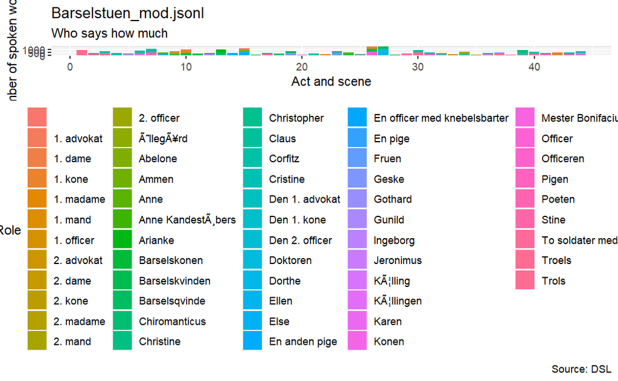

```r
my_summary %>%
  ggplot(aes(fill = speaker, y = words, x = scene_index)) +
    geom_bar(stat="identity") +
    theme(legend.position="bottom") +
    labs(
      title = my_file,
      subtitle = "Who says how much",
      caption = "Source: DSL",
      fill = "Role"
    ) +
  xlab("Act and scene") +
  ylab("Number of spoken words")
```

## Merge different spellings of character-names

In the above plot we can see that multiple roles appear in different spelling. However, we can easily change it.

First, we’ll make a list of all roles in e.g. “Barselstuen”. Remember to change the title.

```r
print(my_summary %>%
        ungroup() %>%
  select(speaker) %>%
  distinct(speaker) %>%
  arrange(speaker), n=60)
```

| speaker |
| --- |
| 1. advokat |
| 1. dame |
| 1. kone |
| 1. madame |
| 1. mand |
| 1. officer |
| 2. advokat |
| 2. dame |
| 2. kone |

[output cut: 47 more lines]

Now we can use two R functions: `if_else()` and `%in%`. The first takes three arguments: first, a logical expression. If this expression is True, the result of the second argument is returned. If it is False, the third argument is returned. See example below:

```r
if_else(2==2, "Correct", "FAKE NEWS")
```

```
[1] "Correct"
```

```r
if_else("Trump"=="Smart", "Correct", "FAKE NEWS")
```

```
[1] "FAKE NEWS"
```

```r
12 %in% c(1,2,3,4)
```

```
[1] FALSE
```

```r
12 %in% c(1, 2, 3, 12, 24)
```

```
[1] TRUE
```

With these two functions we can now write the following code.

Remember that these changes are made for “Barselstuen”, since we are still working with the particular play. We will need to change the below code when working with another play.

[figure not shown]

```r
my_summary %>% pull(scene_number) %>% max() -> number_of_scenes

my_summary %>%
  ungroup() %>%

  # Count all versions of "Leander" as one
  mutate(
    speaker = if_else(speaker %in% c("Leander", "Leander på Knæ"), "Leander", speaker)) %>%

  # Count all versions of "Barselskvinden" as one
  mutate(
    speaker = if_else(speaker %in% c("Barselskonen", "Barselskvinden", "Barselsqvinde"), "Barselskvinden", speaker)) %>%

  # Count all versions of "kællingen" as one
  mutate(
    speaker = if_else(speaker %in% c("Kælling", "Kællingen"), "Kællingen", speaker)) %>%

  ggplot(aes(fill = speaker, y = words, x = scene_index)) +
    geom_bar(stat="identity", width = 50) +
    theme(legend.position="bottom") +
    labs(
      title = my_file,
      subtitle = "Who says how much",
      caption = "Source: DSL",
      fill = "Role"
    ) +
  xlab("Act and scene") +
  ylab("Number of spoken words") +
  facet_wrap(~act_scene, ncol=number_of_scenes, strip.position = "top")+
  theme(axis.text.x=element_blank())
```

# Add a general merge-function of all different spellings of the same character-name, using the excel sheet of name variations

# Read in the excel sheet

```r
variants <- read_excel(here("data", "Rolleliste.xlsx")) %>%
     unnest_tokens(variant, Alias, token = "regex", pattern = ", ") %>%
    mutate(
      Karakter = tolower(Karakter),
      variant = tolower(variant)
    )
```

```
* `` -> ...4
```

```r
variants
```

| Filnavn | Karakter | ...4 | variant |
| --- | --- | --- | --- |
| Abracadabra_mod.jsonl | leander | NA | leander |
| Abracadabra_mod.jsonl | leander | NA | lenader |
| Artaxerxes_mod.jsonl | arbaces | NA | arbaces |
| Artaxerxes_mod.jsonl | arbaces | NA | arbaces sagte. |
| Artaxerxes_mod.jsonl | arbaces | NA | arbaces. |
| Artaxerxes_mod.jsonl | artaxerxes | NA | artaxerxes |
| Artaxerxes_mod.jsonl | artaxerxes | NA | artaxerxes alleene. |
| Artaxerxes_mod.jsonl | artaxerxes | NA | artaxerxes. |
| Artaxerxes_mod.jsonl | semira | NA | semira |
| Artaxerxes_mod.jsonl | semira | NA | semira. |

[output cut: 218 more lines]

## Use the excel sheet

```r
(my_play %>%
  mutate(speaker = tolower(speaker)) %>%
  left_join(variants, by = c("filename"="Filnavn", "speaker"="variant")) %>%
  mutate(speaker = if_else(!is.na(Karakter), Karakter, speaker)) %>%
  distinct -> my_play)
```

| filename | type | docTitle | year | title | act | act_number | scene | scene_number | index | speaker_stage | speaker | spoke | stage | Karakter | ...4 |
| --- | --- | --- | --- | --- | --- | --- | --- | --- | --- | --- | --- | --- | --- | --- | --- |
| Barselstuen_mod.jsonl | 3 | Barselsstuen Komedie | (1724) | Barselsstuen | Første akt | 1 | Scene 1 | 1 | 1 | ( tager op et stykke smalt papir men så langt som det hele theatrum) | troels | NA | NA | troels | NA |
| Barselstuen_mod.jsonl | 4 | Barselsstuen Komedie | (1724) | Barselsstuen | Første akt | 1 | Scene 1 | 1 | 2 | NA | troels | Maren Hansdatter, Barbara Per Nielsens, Abelone Hans Hansens, Christine Erik Eriksens, Engelke Jens Hattemagers, Lusse Frands Buntmagers, Vibeke Per Guldbrandsens, Maren Christopher Skrædders, Elsebe… | NA | troels | NA |
| Barselstuen_mod.jsonl | 4 | Barselsstuen Komedie | (1724) | Barselsstuen | Første akt | 1 | Scene 1 | 1 | 3 | NA | troels | Skal man giftes, må der lige så mange folk komme sammen for at æde og drikke op mere end en stakkels håndværksmand kan fortjene i fire år igen. Derfor har man hittet på den mode i gamle dage at… | NA | troels | NA |
| Barselstuen_mod.jsonl | 4 | Barselsstuen Komedie | (1724) | Barselsstuen | Første akt | 1 | Scene 1 | 1 | 4 | NA | troels | Vil jeg begive mig fra bryllupper til begravelser, da finder jeg lige så megen galskab ved de sidste som ved de første. En stakkels kone mister sin mand, som jeg sætter efterlader hende nogle skill… | NA | troels | NA |
| Barselstuen_mod.jsonl | 4 | Barselsstuen Komedie | (1724) | Barselsstuen | Første akt | 1 | Scene 1 | 1 | 5 | NA | troels | Men disse barselsstuer er rent ravgale. Her skal først et hundrede mennesker gives til kende som et stort vidunder at Hans Hansen eller Jespersen har gjort det mesterstykke ved sin kone som enhver bo… | NA | troels | NA |
| Barselstuen_mod.jsonl | 4 | Barselsstuen Komedie | (1724) | Barselsstuen | Første akt | 1 | Scene 1 | 1 | 6 | NA | troels | Men hvem pokker er det som kommer så løbende? Det er Christophersens karl. Hvad mon han vil? | NA | troels | NA |
| Barselstuen_mod.jsonl | 1 | Barselsstuen Komedie | (1724) | Barselsstuen | Første akt | 1 | Scene 2 | 2 | 1 | NA | NA | NA | Claus, Troels | NA | NA |
| Barselstuen_mod.jsonl | 4 | Barselsstuen Komedie | (1724) | Barselsstuen | Første akt | 1 | Scene 2 | 2 | 2 | NA | claus | Ak, kære Troels, veksl mig en toskilling for to eneste skillinger! | NA | NA | NA |
| Barselstuen_mod.jsonl | 4 | Barselsstuen Komedie | (1724) | Barselsstuen | Første akt | 1 | Scene 2 | 2 | 3 | NA | troels | Hvad vil du med de eneste skillinger? | NA | troels | NA |
| Barselstuen_mod.jsonl | 4 | Barselsstuen Komedie | (1724) | Barselsstuen | Første akt | 1 | Scene 2 | 2 | 4 | NA | claus | Jeg vil give en for at komme op i det runde tårn. | NA | NA | NA |

[output cut: 990 more lines]

## Repeat the preparation of the data

```r
my_play %>%
  select(docTitle) %>%
  distinct() %>%
  pull(1,1) -> my_title

my_play %>%
  select(year) %>%
  distinct() %>%
  pull(1,1) -> my_year


my_play %>%
  # Add a scene index for the x-axis
  rowwise() %>%
  mutate(scene_index = calc_scene_index(act_number, scene_number, act_length)) %>%

  # Add an act_number:scene_number row
  mutate(act_scene = paste(act_number,":",str_pad(scene_number, 2, pad = "0"))) %>%

  # Remove rows that are not dialogue
  filter(act != "", scene != "", !is.na(spoke)) %>%

  # Select only the columns, that we are interested in
  select(scene_index, act_scene, act_number, scene_number, speaker, spoke) %>%

  # Add the number of spoken words
  mutate(n_spoken_words = str_count(spoke, '\\w+')) %>%
  # Remove the spoken words
  select(-spoke) %>%

  # Group the play in scene_index and speaker, ignoring the test
  group_by(scene_index, act_scene, act_number, scene_number, speaker) %>%

  # Ensure that each speaker only appears once in each scene, i.e. sum the words spoken by each speaker
  # Lastly store the new data frame in a new reference for later use
  summarise(words = sum(n_spoken_words), act_number, scene_number) %>%
  distinct() -> my_summary
#print(barselsstuen_vis, n=60)
my_summary
```

| scene_index | act_scene | act_number | scene_number | speaker | words |
| --- | --- | --- | --- | --- | --- |
| 1 | 1 : 01 | 1 | 1 | troels | 897 |
| 2 | 1 : 02 | 1 | 2 | claus | 197 |
| 2 | 1 : 02 | 1 | 2 | troels | 216 |
| 3 | 1 : 03 | 1 | 3 | corfitz | 279 |
| 3 | 1 : 03 | 1 | 3 | troels | 359 |
| 4 | 1 : 04 | 1 | 4 | corfitz | 348 |
| 5 | 1 : 05 | 1 | 5 | corfitz | 169 |
| 5 | 1 : 05 | 1 | 5 | jeronimus | 145 |
| 6 | 1 : 06 | 1 | 6 | corfitz | 422 |
| 6 | 1 : 06 | 1 | 6 | jeronimus | 258 |

[output cut: 112 more lines]